# Korelacja i regresja

Tomasz Przechlewski

Powiślańska Szkoła Wyższa (Kwidzyn/Poland)  
t.plata-przechlewski@psw.kwidzyn.edu.pl

21/2/2026

## Związek pomiędzy zmiennymi, korelacja

Jeżeli wartości jednej zmiennej się zmieniają a drugiej są stałe, to nie ma zależności pomiędzy zmiennymi. Jeżeli wraz ze zmianą wartości jednej zmiennej druga też się zmienia to taka zależność istnieje. Wstępną oceną zależności jest **korelacyjny wykres rozrzutu**.

**Korelacja** to miara siły i kierunku współzależności między dwiema zmiennymi. Miarą korelacji liniowej jest współczynnik korelacji, który może przyjąć wartości z przedziału $[-1,1]$. Im większa, co do wartości bezwzględnej wartość współczynnika, tym związek pomiędzy zmiennymi jest silniejszy. Wartość (bliska) zeru świadczy o braku zależności.

Współczynnik korelacji liniowej nie ma miana, tj. jest **liczbą bezwymiarową** (tzw. goła liczba:-))

Współczynnik korelacji tradycyjnie oznaczamy małą literą $r$.

**Typowa analiza**: $r$ szacujemy na podstawie próby. W takiej sytuacji oprócz oceny punktowej, należy podać przedział ufności oraz zweryfikować hipotezę, że wartość $r$ jest istotnie różna od zera (co by potwierdzało istnienie związku między zmiennymi). Jeżelie nie uda się odrzucić $H_0: r=0$, to przyjmujemy, że nie udało na się wykazać iż istnieje związek pomiędzy zmiennymi.

### Przykład (Machin s.150–152)

Zmierzono poziom hemoglobiny (`Hb`), hematokrytu (`PCV`) oraz wiek (`age`) u 20 pacjentek. Dane są w pliku `hb-pcv-age.csv`. Czy istnieje związek pomiędzy `Hb` i `PCV` oraz `PCV` i `age`?

Zależność `Hb` oraz `PCV`. Korelacyjny wykres rozrzutu, niebieska linia to prosta najlepiej dopasowana do kropek. Część programów potrafi taką kreskę narysować, część nie. Jak program, który używamy nie potrafi, no to trudno…

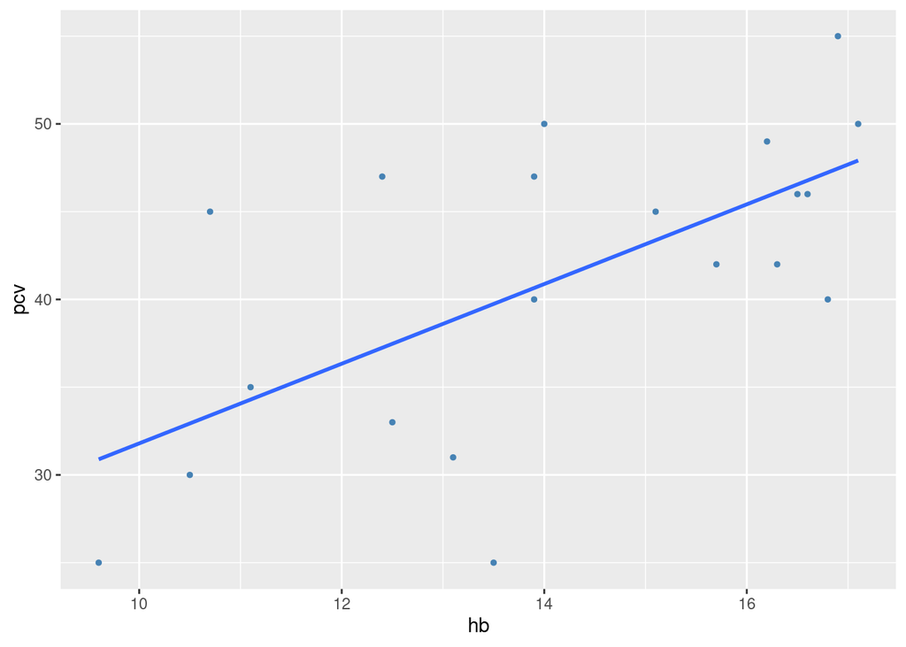

Ocenę punktową współczynnika korelacji liniowej, przedział ufności oraz wynik weryfikacji hipotezy $H_0: r=0$ zawiera następujący wydruk z programu statystycznego:

```
##
##  Pearson's product-moment correlation
##
## data:  machin$hb and machin$pcv
## t = 3.4636, df = 18, p-value = 0.002772
## alternative hypothesis: true correlation is not equal to 0
## 95 percent confidence interval:
##  0.2636603 0.8398783
## sample estimates:
##       cor
## 0.6323962
```

Punktowa ocena to 0.6323962; 95% przedział ufności to 0.2636603, 0.8398783; weryfikację hipotezy dokonujemy w oparciu o wartość $p$ (`p-value` na wydruku): jeżeli jest ona mniejsza od przyjętego poziomu istotności to $H_0$ odrzucamy. W tym przypadku $p$ jest równe 0.0027721 a poziom istotności jest równy 0,05. Hipotezę zerową należy odrzucić, $r$ jest istotnie różne od zera.

Zależność `PCV` oraz `age`. Korelacyjny wykres rozrzutu, niebieska linia to prosta najlepiej dopasowana do kropek. Część programów potrafi taką kreskę narysować, część nie. Jak program, który używamy nie potrafi, no to trudno…

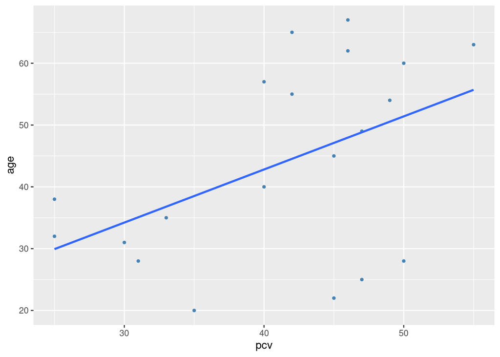

```
##
##  Pearson's product-moment correlation
##
## data:  machin$pcv and machin$age
## t = 2.2637, df = 18, p-value = 0.03618
## alternative hypothesis: true correlation is not equal to 0
## 95 percent confidence interval:
##  0.03564925 0.75581732
## sample estimates:
##       cor
## 0.4707438
```

Punktowa ocena to 0.4707438; 95% przedział ufności to 0.0356493, 0.7558173; weryfikację hipotezy dokonujemy w oparciu o wartość $p$ (`p-value` na wydruku): jeżeli jest ona mniejsza od przyjętego poziomu istotności to $H_0$ odrzucamy. W tym przypadku $p$ jest równe 0.0361843 a poziom istotności jest równy 0,05. Hipotezę zerową należy odrzucić, $r$ jest istotnie różne od zera.

Zauważmy, że gdybyśmy jednakprzyjęli poziom istotności równy 0,01 to wtedy nie byłoby podstaw do odrzucenia hipotezy zerowej.

## Analiza wariancji i regresja

Stochastyczna niezależność

$y∣X \sim F(θ)$

powyższe oznacza: dla każdej wartości $X$, $y$ ma ten sam rozkład prawdopodobieństwa, zdefiniowany przez (wektor parametrów) $θ$.

Przykładowo jeżeli jakaś zmienna $y$ ma dla każdej wartości $X$ ten sam rozkład normalny o wartości oczekiwanej $\mu$ oraz wariancji $\sigma^2$, to $y$ oraz $X$ są niezależne. Wiedza na temat $X$ nic nam nie mówi n/t wartości $y$.

Stochastyczna zależność:

$y|X \sim F(θ(X)) \tag{1}$

powyższe oznacza: zmienna losowa $y$, warunkowo względem $X$, ma rozkład z rodziny $F$, którego parametry $θ$ zależą od $X$. Rozkład prawdopodobieństwa zmiennej $y$ zależy od zmiennej X. Istnieje związek (zależność) pomiędzy $y$ i $X$.

Wartość oczekiwana (albo średnia) zmiennej $y$, warunkowo względem $X$, jest dana przez funkcję $f$ zależną od $X$ i parametrów $β$, co można zapisać jako:

$E(y|X) = f(X, \beta) \tag{2}$

## Analiza wariancji (ANOVA)

Równania (1–2) można zapisać bardziej precyzyjnie:

$$\begin{aligned}
y∣X \sim N(μ(X), σ^2)\\
E(y∣X) = μ(X)
\end{aligned}$$

Rozkład $F$ ze wzorów (1–2) definiujemy jako rozkład normalny o średniej $μ(X)$ oraz wariancji $σ^2$ (pierwszy wiersz) **oraz** dla każdej wartości $X$ średnia $y$ jest równa $μ(X)$.

Rozkład w populacji generalnej $y$ zależy od wartości $X$. Zmienna $X$ jest **zmienną nominalną** przyjmującą $k$ wartości zwanych poziomami; jeżeli $X$ to płeć, to są dwa poziomy: $K$ oraz $M$.

Teraz $μ(K)$ oznacza średnią dla kobiet a $μ(M)$ średnią dla mężczyzn.

**Typowa analiza**: pobieramy z populacji próbę i na tej podstawie chcemy ocenić czy średnie wartości w populacji różnią się istotnie (albo: średnia wartość zmiennej $y$ jest różna w różnych grupach wyznaczonych przez zmienną $X$). Dla $k$-poziomów można zapisać hipotezę zerową formalnie jako:

$$H_0: μ_1 = μ_2 = ... = μ_k$$

### Przykład (kontynuacja poprzedniego)

Zmienna `age3` zawiera wiek pacjentek zmierzony w 3-stopniowej skali nominalnej (niski, średni, wysoki). Pytanie czy średni poziom `Hb` w grupach wyznaczonych przez `age3` jest równy czy różny? Średnie w grupach można łatwo policzyć i wynoszą one:

| age3 | m |
| --- | --- |
| niski | 11.629 |
| wysoki | 16.600 |
| średni | 14.486 |

Czy te różnice są istotne. Do tego właśnie służy (test) anova. Następujący wydruk z programu statystycznego zawiera wynik testu:

```
##
##  One-way analysis of means (not assuming equal variances)
##
## data:  hb and age3
## F = 32.959, num df = 2.0000, denom df = 9.5924, p-value = 0.00005038
```

Patrzymy na `p-value`, tutaj równe 0.0000504. Ponieważ jest to wartość mniejsza od 0,05 zatem na poziomie istotności 0,05 należy odrzucić hipotezę że wartości wszystkich średnich są równe.

## Analiza regresji

Równania (1–2) można zapisać bardziej precyzyjnie:

$$\begin{align}
y|X \sim N(Xβ, σ^2) \tag{1'}\\
E(y∣X)= Xβ \tag{2'}
\end{align}$$

Rozkład $F$ ze wzorów (1–2 ) definiujemy także jako rozkład normalny, ale o średniej $Xβ$ oraz wariancji $σ^2$.

Zapis: $Xβ$ oznacza kombinację liniową zmiennych objaśniających (w interpretacji graficznej: prosta lub ogólnie $p$-wymiarowa hiperpłaszczyzna); jeżeli $X$ oznacza jedną zmienną, np. $x$, to mamy $β_0 + β_1 x$ (równanie prostej).

Ogólnie: jeśli: $X=(1,x_1,x_2,…,x_p)$ oraz $β=(β_0,β_1,β_2,…,β_p)^T$ to: $Xβ=β_0+β_1x_1+β_2x_2+⋯+β_px_p$

czyli: suma zmiennych $x_i$ pomnożonych przez współczynniki $β_i$

Zamiast równań (1’–2’) równanie regresji można zapisać następująco:

$$y = Xβ + \epsilon$$

gdzie $\epsilon \sim N(0, \sigma^2)$. Jeżeli teraz obliczymy średnią (wartość oczekiwaną mówiąc precyzyjnie) to otrzymamy $E(y|X) = X\beta$, bo zakładamy, że $E(\epsilon) = 0$. Średnie wartości $y$ są równe kombinacji liniowej $X$, albo $X$ objaśnia zmienność $y$ (w sensie statystycznym), czyli: znając $X$, możemy przewidywać $y$.

Oceny parametrów $β$ uzyskuje się za pomocą **metody najmniejszych kwadratów** (MNK), w której minimalizuje się sumę kwadratów różnic między wartościami obserwowanymi $y$ a wartościami teoretycznymi $\hat y$, przy czym $\hat y =Xβ$ oznacza wartość zmiennej $y$ wyznaczoną na podstawie modelu (teoretyczną). W przypadku kiedy $X$ oznacza jedną zmienną można to przedstawić na rysunku.

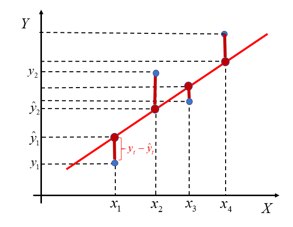

**Typowa analiza**: Opisanie zależności między **zmienną zależną** (objaśnianą) $y$ a jedną lub wieloma **zmiennymi niezależnymi** (objaśniającymi). Pozwala ustalić kierunek i siłę związku między zmiennymi oraz przewidywać wartości zmiennej zależnej dla nowych danych.

Analiza regresji składa się z trzech etapów:

1. wyznaczenie wartości parametrów $\beta$ (na podstawie próby)
2. ocena dopasowania modelu
3. ocena spełnienia założeń co do wykorzystywanego modelu

Interpretacja parametrów modelu: jeżeli wartość zmiennej $X$ rośnie o jednostkę to wartość zmiennej $y$ zmienia się przeciętnie o $b_1$ jednostek zmiennej $y$.

Ponieważ współczynniki regresji $b_1, …, b_k$ mogą być wyrażone w różnych jednostkach miary, bezpośrednie ich porównanie jest niemożliwe; mały współczynnik może w rzeczywistości być ważniejszy niż większy. Jeżeli chcemy porównywać wielkości współczynników, to trzeba je **zestandaryzować**.

Standaryzowany współczynnik regresji dla $i$-tej zmiennej obliczony jest poprzez pomnożenie współczynnika regresji $b_i$ przez $s_{xi}$ i podzielenie przez $s_y$:

$$\beta_i = b_i
\frac{s_{x}}{s_y}$$

Dla przypomnienia: $s_{x}$ to odchylenie standardowe zmiennej $X$, a $s_y$ to odchylenie standardowe zmiennej $y$. Interpretacja współczynnika standaryzowanego jest cokolwiek dziwaczna: zmiana zmiennej $X_i$ o jedno odchylenie standardowe ($s_{xi}$) skutkuje zmianą zmiennej $Y$ o $b_i$ jej odchylenia standardowego $s_y$. Na szczęście współczynniki regresji standaryzuje się nie w celu lepszej interpretacji, tylko w celu umożliwienia porównania ich względnej wielkości. W publikacjach medycznych zwykle używa się litery $b$ na oznaczenie współczynników niestandaryzowanych, a litery $\beta$ na oznaczenie współczynników standaryzowanych.

Do oceny dopasowania modelu do danych używamy **reszt** (ang. *residual*), tj. różnic pomiędzy wartościami zmiennej $y$ obliczonej na podstawie modelu, a wartościami $y$ zaobserwowanymi w próbie:

$$\hat e_i = y_i - \hat y_i$$

gdzie:

$\hat e_i$ jest $i$-tą resztą (odpowiadającą $i$-tej obserwacji w próbie);

$\hat y_i = X_i \hat \beta_i$ jest $i$-tą wartością zmiennej $y$ obliczoną na podstawie modelu (tj dla wartości $X_i$);

$\hat \beta_i$ jest oceną (oszacowaniem) prawdziwej wartości $\beta_i$ (której nigdy nie znamy)

**Wariancją resztową** (*error variance*) nazywamy:

$$s_e^2 = \frac{\sum_{i=1}^n e_i^2}{n - k
- 1 }$$

gdzie: $n$ oznacza liczebność próby a $k$ liczbę zmiennych $X$.

Pierwiastek kwadratowy z $s_e^2$ nazywamy **średnim błędem szacunku** (*mean squared error* albo MSE)

Zawsze jest spełnione $\sum_{i=1}^n \hat e_i = 0$

Można udowodnić, że prawdziwe jest:

$$\sum_{i=1}^n (y_i - \bar y)
= \sum_{i=1}^n (\hat y_i - \bar y_i) + \sum_{i=1}^n \hat e_i^2$$

$OSK = \sum_{i=1}^n (y_i - \bar y)$ to ogólna suma kwadratów;

$WSK = \sum_{i=1}^n (\hat y_i - \bar y_i)$ to wyjaśniona (przez model) suma kwadratów;

$RSK = \sum_{i=1}^n (y_i - \bar y)$ resztowa suma kwadratów;

Zatem:

$$OSK = WSK + RSK$$

Po podzieleniu przez $OSK$ otrzymujemy:

$$1 = WSK/OSK + RSK/OSK$$

Wielkość $WSK/OSK$ nazywamy **współczynnikiem determinacji** i oznaczamy jako $R^2$ (R-kwadrat).

Interpretacja: udział (procent) zmienności zmiennej $y$ objaśniany przez model.

Można wykazać, że jeżeli faktycznie $\epsilon \sim N(0, \sigma^2)$ wtedy oceny współczynników $\hat\beta_i$ mają rozkład $t$-Studenta. Znając rozkład $\hat\beta_i$ można zweryfikować hipotezę:

$H_0: \beta_i = 0$

względem hipotezy alternatywnej

$H_1: \beta_i \not = 0$

Odrzucenie $H_0$ oznacza, że _i jest istotnie różny od zera, tj. istnieje zależność pomiędzy $y$ oraz $X$.

**Podsumowanie**: ocena dopasowania modelu = obliczenie $\hat e$, $R^2$ oraz zweryfikowanie hipotez postaci $H_0: \beta_i = 0$.

Oceny spełnienia założeń co do wykorzystywanego modelu dokonuje się weryfikując stosowne testy statystyczne (patrz przykład)

**Raport powinien zawierać**: oszacowania punktowe i przedziałowe parametrów, współczynniki standaryzowane, średni błąd szacunku, współczynnik determinacji oraz wyniki weryfikacji hipotez dotyczących istotności poszczególnych parametrów modelu.

### Przykład (kontynuacja poprzedniego)

Hipoteza badawcza: poziom hemoglobiny jest istotnie zależny od wartości PCV oraz wieku pacjentki:

$$\textrm{Hb} = \textrm{PCV} +
\textrm{age}$$

Następujący wydruk z programu statystycznego zawiera oszacowanie modelu:

```
##
## Call:
## lm(formula = hb ~ pcv + age, data = machin)
##
## Residuals:
##     Min      1Q  Median      3Q     Max
## -1.9118 -0.7108  0.1003  0.6156  1.5758
##
## Coefficients:
##             Estimate Std. Error t value   Pr(>|t|)
## (Intercept)  5.90722    1.16187   5.084 0.00009191 ***
## pcv          0.07814    0.03111   2.511     0.0224 *
## age          0.11410    0.01705   6.693 0.00000378 ***
## ---
## Signif. codes:  0 '***' 0.001 '**' 0.01 '*' 0.05 '.' 0.1 ' ' 1
##
## Residual standard error: 1.032 on 17 degrees of freedom
## Multiple R-squared:  0.8349, Adjusted R-squared:  0.8155
## F-statistic: 42.99 on 2 and 17 DF,  p-value: 0.0000002241
```

Po wyrazie `Coefficients:` mamy oceny punktowe parametrów (kolumna `Estimate`), średnie błędy ocen parametrów (kolumna `Str. error`) oraz wartości $p$ (kolumna `Pr(>|t|)`. Poniżej na wydruku można odszukać: współczynnik determinacji (`Multiple R-squared` oraz średni błąd szacunku (`Residual standard error`).

Brakuje oszacowań przedziałowych oraz wielkości standaryzowanych. Część programów statystycznych drukuje wszystko co potrzebujemy od razu, część tego nie nie potrafi i trzeba to doliczyć osobno. Mój nie potrafi. Tak czy siak, w raporcie należy zestawić wszystko razem, najlepiej w postaci tabeli:

| Zmienna | B | SE | z | p | Beta | CI95 |
| --- | --- | --- | --- | --- | --- | --- |
| (Intercept) | 5.907 | 1.162 | 5.084 | 0.000 | NA | 3,46 8,36 |
| pcv | 0.078 | 0.031 | 2.511 | 0.022 | 0.28 | 0,01 0,14 |
| age | 0.114 | 0.017 | 6.693 | 0.000 | 0.75 | 0,08 0,15 |

Pod tabelą należy umieścić wartość współczynnika determinacji (83.4915774%) oraz średniego błędu szacunku (1.0317094).

ChatGPT: Jak policzyć przedziały ufności i wielkości standaryzowane dla wsp. regresji w R oraz w gretlu?

https://chatgpt.com/c/69dc8368-2b60-8330-8df2-83f7518f8f0f

## Regresja logistyczna

Jeżeli $p$ oznacza prawdopodobieństwo to $\frac{p}{1-p}$ jest **szansą** (*odds*);

Potocznie prawdopodobieństwo i szansa to (prawie) to samo, ale nie w statystyce: prawdopodobieństwo to liczba z przedziału $[0,1]$ podczas gdy szansa to liczba z przedziału $[0,\infty]$

Przykładowo:

[output not shown]

Stosunek szansy (wystąpienia zdarzenia) w jednej grupie do szansy jego wystąpienia w innej grupie określa się jako iloraz szans (*odds ratio*, OR)

Właściwości:

$OR < 1$ szansa wystąpienia zdarzenia w pierwszej grupie jest mniejsza niż w drugiej.

Przykładowo: $OR=0.9$ – szansa wystąpienia zdarzenia w grupie 1 jest 10% mniejsza niż w grupie 2. $OR=0.05$ – szansa wystąpienia zdarzenia w grupie 1 jest 95% mniejsza niż w grupie 2 (albo 20 razy mniejsza)

Ogólnie: procentowa zmiana szans = $(OR − 1) \times 100$%

$OR = 1$ szansa wystąpienia zdarzenia w obu grupach jest identyczna;

$OR > 1$ szansa wystąpienia zdarzenia w pierwszej grupie jest większa niż w drugiej

Wiedząc teraz co to jest $OR$ możemy przejść do modelu regresji logistycznej.

**W modelu regresji logistycznej zmienna $y$ jest zmienną binarną, tj. taką która może przyjąć tylko dwie wartości (np. umarł/żyje); z tego powodu nie da zastosować modelu „normalnej” regresji**. Typowa sytuacja to ustalenie zależności pomiędzy zachorowaniem na osteoporozę ($y$, binarna), a płcią, wiekiem oraz poziomem witaminy D.

Jedną z wartości zmiennej $y$ określa się jako **sukces** (wystąpienie choroby, śmierć, itd) i przypisuje jej wartość 1, natomiast drugą wartość określa się jako **porażka** (brak choroby) i przypisujej jej wartość 0.

W modelu regresji logistycznej równania (1–2) można zapisać bardziej precyzyjnie jako:

$$\begin{align}
y|X \sim B(1, p(X)) \tag{1''}\\
E(y|X) = p = \frac{\exp(X \beta )}{(1 + \exp (X \beta)}
\tag{2''}
\end{align}$$

Zmienna $y$ dla każdej wartości $X$ ma rozkład dwumianowy z prawdopodobieństwem sukcesu $p$ zależnym od wartości zmiennych $X$ (równanie 1’’)

Średnia wartość zmiennej $y$ dla każdej wartości $X$ (która w rozkładzie dwumianowym jest równa $p$) jest określona przez dziwną formułę po prawej równania 2’’:

$$\frac{\exp(X \beta )}{(1 + \exp (X \beta)}$$

gdzie $\exp(x)$ oznacza $e^x$ ($e$ to podstawa logarytmu naturalnego, $e\approx 2,7182...$)

Szczęśliwie równanie (2’’) można przedstawić w wersji równoważnej:

$$\ln(\frac{p}{1-p}) = X
\beta$$

gdzie $\ln$ oznacza logarytm naturalny (czyli przy podstawie $e$)

Zauważmy, że $\frac{p}{1-p}$ to szansa; czyli po lewej stronie równania mamy **logarytm szansy**; takie coś nosi nazwę **logit**, tj.:

$$\textrm{logit}(p) = \ln(\frac{p}{1-p})$$

Teraz najciekawsze:

Rozważmy model z jedną zmienną:

$$\ln(o)= \beta_0 + \beta_1 W$$

gdzie: $o$ oznacza szansę wystąpienia osteoporozy, a $W$ oznacza wiek. Obliczmy różnicę pomiędzy $\ln(o)$ dla wartości $W=w$ oraz $W=w+1$ (czyli dla zmiany o jednostkę):

$$\begin{align}
\ln (o_{w+1}) - \ln(o_{w}) =\\
\beta_0 + \beta_1 (w + 1 ) - (\beta_0 + \beta_1 (w)) = \beta_1
\end{align}$$

gdzie $o_{w}$ szansa osteoporozy przy wieku równym $w$; $o_{w+1}$ szansa osteoporozy przy wieku równym $w + 1$

Obustronnie delogarytmując powyższe równanie otrzymujemy ostatecznie:

$$\frac{o_{w+1}}{o_{w}} =
e^{\beta_1}$$

Czyli $e^{\beta_1}$ jest **ilorazem szans**; grupa 1 to osoby w wieku $w$, a grupa 2 to osoby w wieku $w+1$; albo inaczej: każdy dodatkowy rok oznacza wzrost (lub spadek w zależności od wartości $e^\beta_1$) szansy na osteoporozę o $(e^{\beta_1} − 1) \times 100$%.

Jeżeli model zawiera więcej niż jedną zmienną $X$ to powyższa interpretacja dalej obowiązuje: jeżeli $X_i$ wzrośnie to iloraz szans zmieni się o $(e^{\beta_i} − 1) \times 100$%, przy założeniu że pozostałe zmienne $X$ mają ustalone wartości.

Ocena dopasowania modelu

Nie ma w przypadku regresji logistycznej możliwości obliczenia sumy kwadratów reszt czy współczynnika zbieżności. Model ocenia się, używając jako kryterium **dewiancję** (*deviance*), której wielkość zależy od proporcji pomiędzy liczbą sukcesów obliczonych na podstawie modelu a liczbą sukcesów zaobserwowanych. Dewiancja będzie tym większa, im różnica między tymi teoretycznymi liczebnościami a liczebnościami empirycznymi będzie większa.

Porównuje się wielkość dewiancji szacowanego modelu z modelem zerowym (*null model*), tj. modelem, w którym po prawej stronie równania występuje tylko stała.

Zamiast współczynnika zbieżności $R^2$ stosuje się współczynniki pn. pseudo-$R^2$, takie jak pseudo-$R^2$ McFaddena lub pseudo-$R^2$ Nagelkerke. Ich interpretacja jest podobna do „normalnego“ $R^2$: im bliżej zera, tym gorzej, im bliżej jedności, tym lepiej.

Minimalne kryteria oceny przydatności modelu regresji logistycznej: mała dewiancja, duże wartości współczynników pseudo-$R^2$, dewiancja istotnie mniejsza od modelu zerowego oraz istotnie różne od zera parametry przy zmiennych niezależnych.

Raport powinien zawierać: oszacowania punktowe parametrów, punktowe i przedziałowe wartości oceny ilorazu szans oraz wyniki weryfikacji hipotez dotyczących istotności poszczególnych parametrów plus wartość dewiancji, weryfikację jej istotności oraz wartości współczynników pseudo-$R^2$.

### Przykład (kontynnuacja poprzedniego)

Zmienna `anemia` ma wartość 1 jeżeli stwierdzono anemię, a wartość 0 jeżeli jej nie stwierdzono (plik `hb-pcv-age.csv`).

Hipoteza badawcza: ryzyko wystąpienia anemii jest istotnie zależne od wartości PCV oraz wieku pacjentki:

$$\textrm{logit}(p) = β₀ + β₁\textrm{PCV} + β₂\textrm{wiek}$$

gdzie $p$ oznacza prawdopodobieństwo wystąpienia anemii.

Następujący wydruk z programu statystycznego zawiera oszacowanie modelu:

```
##
## Call:
## glm(formula = anemia ~ pcv + age, family = "binomial", data = machin)
##
## Coefficients:
##             Estimate Std. Error z value Pr(>|z|)
## (Intercept)  27.0854    18.0355   1.502    0.133
## pcv          -0.3027     0.2136  -1.417    0.156
## age          -0.5797     0.3949  -1.468    0.142
##
## (Dispersion parameter for binomial family taken to be 1)
##
##     Null deviance: 20.0161  on 19  degrees of freedom
## Residual deviance:  6.7866  on 17  degrees of freedom
## AIC: 12.787
##
## Number of Fisher Scoring iterations: 9
```

Po wyrazie `Coefficients:` mamy oceny punktowe parametrów (kolumna `Estimate`), średnie błędy ocen parametrów (kolumna `Str. error`) oraz wartości $p$ (kolumna `Pr(>|t|)`. Poniżej na wydruku można odszukać: dewiancję modelu zerowego (`Null deviance`) oraz dewiancję modelu estymowanego (`Residual deviance`).

Brakuje ilorazów szans oraz przedziałów ufności dla ilorazów szans. Brakuje też współczynników pseudo-$R^2$ oraz weryfikacji istotności różnicy modelu estymowanego względem zerowego (potocznie: czy model jest istotny). Część programów statystycznych drukuje wszystko co potrzebujemy od razu, część tego nie nie potrafi i trzeba to doliczyć osobno. Mój nie potrafi. Tak czy siak, w raporcie należy zestawić wszystko razem, najlepiej w postaci tabeli:

| Parametr | Ocena | SE | z | p | OR | CI95 |
| --- | --- | --- | --- | --- | --- | --- |
| (Intercept) | 27.085 | 18.036 | 1.502 | 0.133 | 579479922094.31 | 115,04 14727205989186506252183413102393425920,00 |
| pcv | -0.303 | 0.214 | -1.417 | 0.156 | 0.74 | 0,37 0,99 |
| age | -0.580 | 0.395 | -1.468 | 0.142 | 0.56 | 0,15 0,90 |

Wzrost wartości PCV o 1% oznacza zmniejszenie szansy na anemię o 26%; Każdy dodatkowy rok zmniejsza szansę na anemię o 44%. Obie wartości **nie są** istotne statystycznie, o czym świadczą wartości $p$ wynoszące odpowiednio $0,156$ oraz $0,142$.

Model jest istotny (ponieważ $p$ jest równe 0.0013405); wartość pseudo-$R^2$ Nagelkerke wynosi 0.7651754; wartość pseudo-$R^2$ McFaddena wynosi 0.6609414.

Gdybyśmy estymowali model używając liczeniejszej próby a nie nędznych 20 pacjentek, to zapewne oceny parametrów byłyby istotne i wszyscy by żyli długo i szczęśliwie :-)

## Framingham Heart Study

Projekt Framingham (Framingham Heart Study) to jedno z najważniejszych i najdłużej trwających badań epidemiologicznych w historii medycyny.

Został rozpoczęty w 1948 roku w mieście Framingham i miał na celu zrozumienie, jakie czynniki wpływają na rozwój chorób serca.

https://en.wikipedia.org/wiki/Framingham_Heart_Study

Jeden z wariantów tego zbioru dostępny po zainstalowaniu pakietu `riskCommunicator` w środowisku R. Zbiór ten zawiera m.in. następujące zmienne:

- PERIOD: Examination Cycle. 1 = Period 1 (n = 4434), 2 = Period 2 (n = 3930), 3 = Period 3 (n = 3263)
- SEX: 1=male, 2=female
- TOTCHOL: Serum Total Cholesterol (mg/dL)
- TOTCHOL3: Serum Total Cholesterol (nominal scale: Low/Medium/High)
- AGE: age in years at exam.
- AGE3: age in years at exam (nominal scale: Low/Medium/High)
- SYSBP: Systolic Blood Pressure
- DIABP: Diastolic Blood Pressure
- CURSMOKE = Current cigarette smoking at exam. 0 = Not current smoker, 1 = Current smoker
- CIGPDAY: Number of cigarettes smoked each day. 0 = Not current smoker.
- BMI: Body-mass index
- BMI3: Body-mass index (nominal scale: Low/Medium/High)
- DIABETS: 0 = not a diabetic, 1 = Diabetic
- BPMEDS: Use of Anti-hypertensive medication at exam. 0 = Not currently used, 1 = Current use.
- HEARTRTE: heart rate.
- GLUCOSE: Casual serum glucose (mg/dL).
- PREVMI: Prevalent Myocardial Infarction. 0 = Free of disease, 1 = Prevalent disease. (Przebyty zawał mięśnia sercowego.)
- PREVSTRK = Prevalent Stroke. 0 = Free of disease, 1 = Prevalent disease.
- REVHYP = Prevalent Hypertensive. 0 = free ; 1 = prevalent disease (Nadciśnienie tętnicze)
- DEATH: Death from any cause. 0 = Did not occur during followup, 1 = Did occur during followup.
- ANGINA Angina Pectoris. 0 = Did not occur during followup, 1 = Did occur during followup. (Dławica piersiowa.)
- CVD Myocardial infarction, Fatal Coronary Heart Disease, Atherothrombotic infarction, Cerebral Embolism, Intracerebral Hemorrhage, or Subarachnoid Hemorrhage or Fatal Cerebrovascular Disease. 0 = Did not occur during followup, 1 = Did occur during followup.
- TIMEDTH: Number of days from Baseline exam to death if occurring during followup or Number of days from Baseline to censor date
- TIMECVD: Number of days from Baseline exam to first CVD event during followup or Number of days from Baseline to censor date.
- TIMESTRK: Number of days from Baseline exam to first STROKE event

Plik `framingham.csv` ograniczony do pacjentów dla `PERIOD==1`

### Analiza wariancji

cholesterol = BMI3

```
##
##  One-way analysis of means (not assuming equal variances)
##
## data:  TOTCHOL and BMI3
## F = 41.644, num df = 2.0, denom df = 2906.2, p-value <
## 0.00000000000000022
```

### Regresja liniowa

cholesterol = age + BMI + sex + smoking

```
##
## Call:
## lm(formula = TOTCHOL ~ AGE + BMI + SEX + CURSMOKE, data = f0)
##
## Residuals:
##     Min      1Q  Median      3Q     Max
## -135.08  -29.14   -3.38   24.94  461.58
##
## Coefficients:
##              Estimate Std. Error t value             Pr(>|t|)
## (Intercept) 132.82702    6.27370  21.172 < 0.0000000000000002 ***
## AGE           1.26183    0.07718  16.349 < 0.0000000000000002 ***
## BMI           1.10778    0.16262   6.812      0.0000000000109 ***
## SEX           7.15700    1.34304   5.329      0.0000001037764 ***
## CURSMOKE      3.01130    1.37699   2.187               0.0288 *
## ---
## Signif. codes:  0 '***' 0.001 '**' 0.01 '*' 0.05 '.' 0.1 ' ' 1
##
## Residual standard error: 42.9 on 4359 degrees of freedom
##   (70 obserwacji zostało skasowanych z uwagi na braki w nich zawarte)
## Multiple R-squared:  0.07786,    Adjusted R-squared:  0.07701
## F-statistic: 92.01 on 4 and 4359 DF,  p-value: < 0.00000000000000022
```

### Regresja logistyczna

heartDisease = age + BMI + sex + cholesterol + smoking

```
##
## Call:
## glm(formula = CVD ~ AGE + BMI + SEX + TOTCHOL + CURSMOKE, family = "binomial",
##     data = f0)
##
## Coefficients:
##               Estimate Std. Error z value             Pr(>|z|)
## (Intercept) -6.2784360  0.3946974 -15.907 < 0.0000000000000002 ***
## AGE          0.0687396  0.0045666  15.053 < 0.0000000000000002 ***
## BMI          0.0637984  0.0090195   7.073     0.00000000000151 ***
## SEX         -0.8987716  0.0769641 -11.678 < 0.0000000000000002 ***
## TOTCHOL      0.0051134  0.0008423   6.071     0.00000000127474 ***
## CURSMOKE     0.3531643  0.0789542   4.473     0.00000771206342 ***
## ---
## Signif. codes:  0 '***' 0.001 '**' 0.01 '*' 0.05 '.' 0.1 ' ' 1
##
## (Dispersion parameter for binomial family taken to be 1)
##
##     Null deviance: 5012.8  on 4363  degrees of freedom
## Residual deviance: 4477.5  on 4358  degrees of freedom
##   (70 obserwacji zostało skasowanych z uwagi na braki w nich zawarte)
## AIC: 4489.5
##
## Number of Fisher Scoring iterations: 4
```